# ANLY503_HW5_Xin_Lu_p2

Xin

10/19/2020

2. What is the distribution of all loans and what are their characteristics? There are 6 columns related to loans, loan_date, loan_amount, loan_payment, loan_term, loan_status and loan_default. I will look at each column individually and some columns collectively and create graphs shown below to illustrate my findings.

```r
library(tidyverse)
# install.packages("naniar")
library(naniar)
accounts <- read_csv("data/accounts_analytical.csv")
accounts %>% glimpse()
```

```
## Observations: 4,500
## Variables: 64
## $ account_id                                    <dbl> 1, 2, 3, 4, 5, 6, …
## $ acct_creation_date                            <date> 1995-03-24, 1993-…
## $ statement_frequency                           <chr> "monthly", "monthl…
## $ account_district                              <chr> "Pisek", "Hl.m. Pr…
## $ num_customers                                 <dbl> 1, 2, 2, 1, 1, 1, …
## $ credit_cards                                  <dbl> 1, 2, 2, NA, 1, 1,…
## $ loan_date                                     <date> NA, 1994-01-05, N…
## $ loan_amount                                   <dbl> NA, 80952, NA, NA,…
## $ loan_payment                                  <dbl> NA, 3373, NA, NA, …
## $ loan_term                                     <dbl> NA, 24, NA, NA, NA…
## $ loan_status                                   <chr> NA, "expired", NA,…
## $ loan_default                                  <lgl> NA, FALSE, NA, NA,…
## $ max_withdrawal                                <dbl> 7500, 42000, 7400,…
```

[output cut: 51 more lines]

```r
transactions <- read_csv("data/transactions.csv")
transactions %>% glimpse()
```

```
## Observations: 1,056,320
## Variables: 10
## $ id         <dbl> 1, 5, 6, 7, 8, 9, 10, 11, 12, 13, 14, 15, 16, 17, 18,…
## $ account_id <dbl> 1, 1, 1, 1, 1, 1, 1, 1, 1, 1, 1, 1, 1, 1, 1, 1, 1, 1,…
## $ date       <date> 1995-03-24, 1995-04-13, 1995-05-13, 1995-06-13, 1995…
## $ type       <chr> "credit", "credit", "credit", "credit", "credit", "cr…
## $ amount     <dbl> 1000, 3679, 3679, 3679, 3679, 3679, 3679, 3679, 3679,…
## $ balance    <dbl> 1000, 4679, 20977, 26835, 30415, 28903, 22714, 23318,…
## $ bank       <chr> NA, "AB", "AB", "AB", "AB", "AB", "AB", "AB", "AB", "…
## $ account    <dbl> NA, 41403269, 41403269, 41403269, 41403269, 41403269,…
## $ method     <chr> "cash", "bank transfer", "bank transfer", "bank trans…
## $ category   <chr> NA, NA, NA, NA, NA, NA, NA, NA, NA, NA, NA, NA, NA, N…
```

```r
# na.omit(accounts) %>% select(loan_amount, loan_payment)
```

2.1 First I look at if the general situation with loans, such as how many loans in total, if all accounts have loans or only a few accounts have loans. We can tell from the graph below that the majority of accounts (0.85) don’t have loans, represented by the missing value percentage of column loan_date.

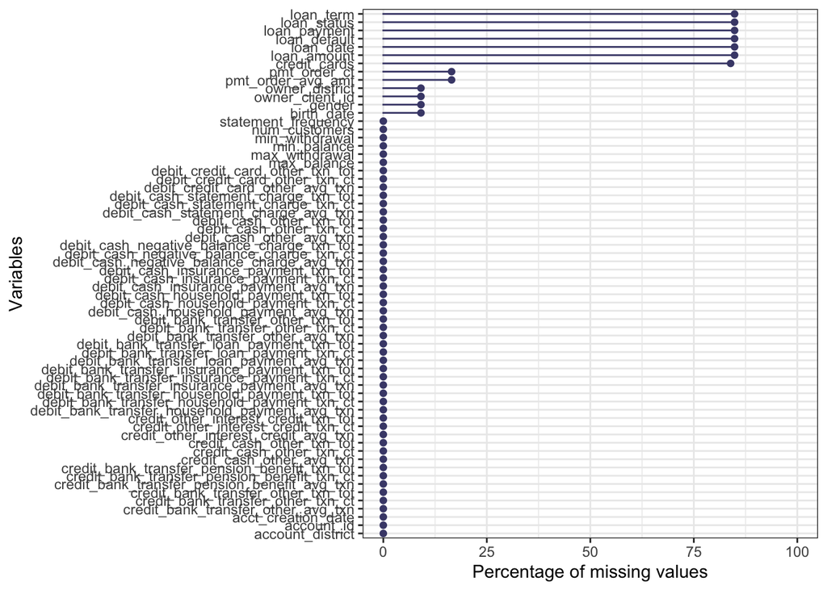

```r
gg_miss_var(accounts, show_pct=T) + # show_pct=T shows proportion of missing
  labs(y = "Percentage of missing values") +
  ylim(0,100) +
  theme_bw()
```

```r
library(scales)
```

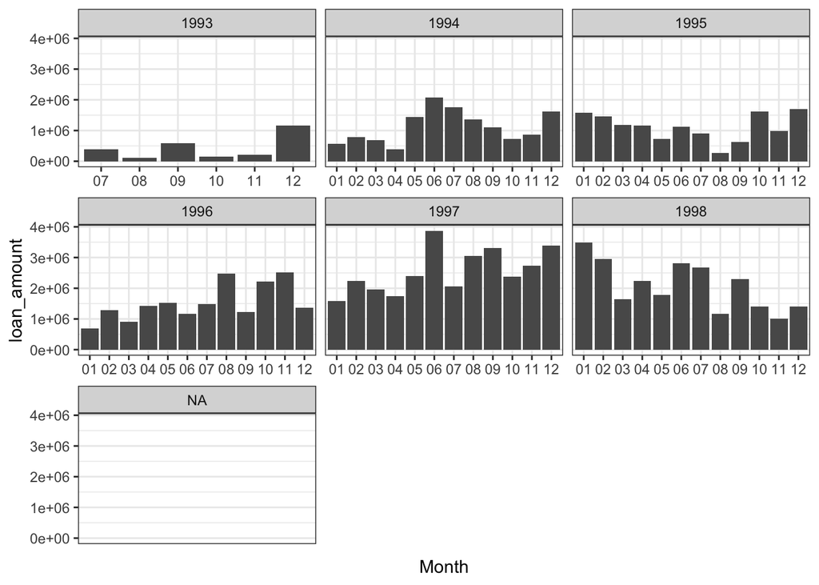

```r
ggplot(
  data = accounts,
  mapping = aes(
    x = format(accounts$loan_date, "%m"),
    y = loan_amount
  )
) +
  geom_bar(stat = "identity")+
  # scale_x_date(labels = date_format("%Y")) +
  facet_wrap(~format(accounts$loan_date, "%Y"), scales=("free_x")) +
  theme_bw() +
  labs(x="Month", y="loan_amount")
```

2.3 Thirdly I look at loan_payment, its overall distributions and percentage of loans paid. From the first graph, which shows the loan_payment of each account with a scatter plot, the distribution of loan_payment is scattered around without any discernible patterns. The range of loan_payment is between 0-10,000.  
From the second graph, which shows the percentage of loan paid by account, we can see there are only 5 percentages, well below 10%, meaning all accounts only paid less than 10% of their total loan, which is a bit weird.

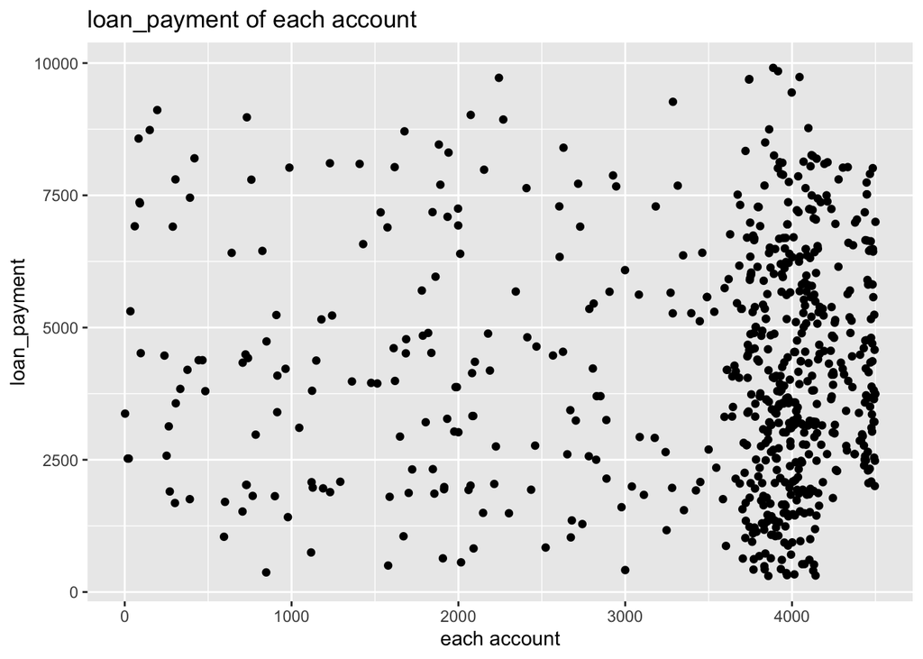

```r
# since account_id is not sequential and there are some skipped account numbers, which can be misleading
# a new sequential id is generated to show loan distribution of each account.
accounts$id <- seq.int(nrow(accounts))

# 1st graph: shows loan_payment of each account using scatter plot
ggplot(
  data = accounts[!(is.na(accounts$loan_date)),],
  mapping = aes(
    x = id,
    y = loan_payment
  )
) +
  geom_point()+
  labs(x="each account", y="loan_payment",
       title = 'loan_payment of each account')
```

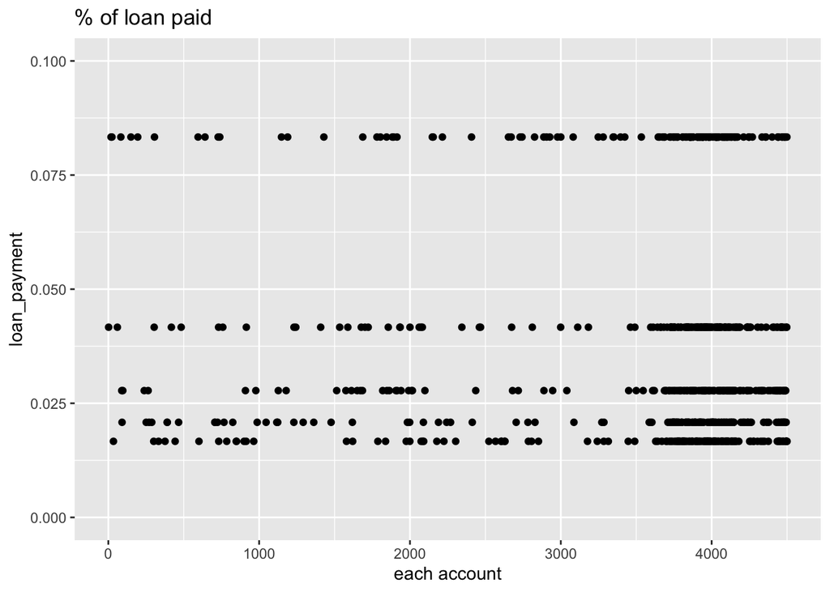

```r
# second graph
ggplot(
  data = accounts[!(is.na(accounts$loan_date)),],
  mapping = aes(
    x = id,
    y = loan_payment/loan_amount
  )
) +
  geom_point()+
  labs(x="each account", y="loan_payment", title = '% of loan paid') +
  ylim(0,0.1)
```

2.4 Next I look at loan_term and its distributions. Per graph 1, which shows count of loan_term, we can see each loan_term is very balanced, there are about the same number of accounts in each category of loan_terms. Per graph 2, which shows sum of loan_amount per loan_term, illustrates that the longer the loan term, the bigger the loan amount. It makes sense because longer terms usually means customers are getting a bigger loan so they can even out the payment each month.

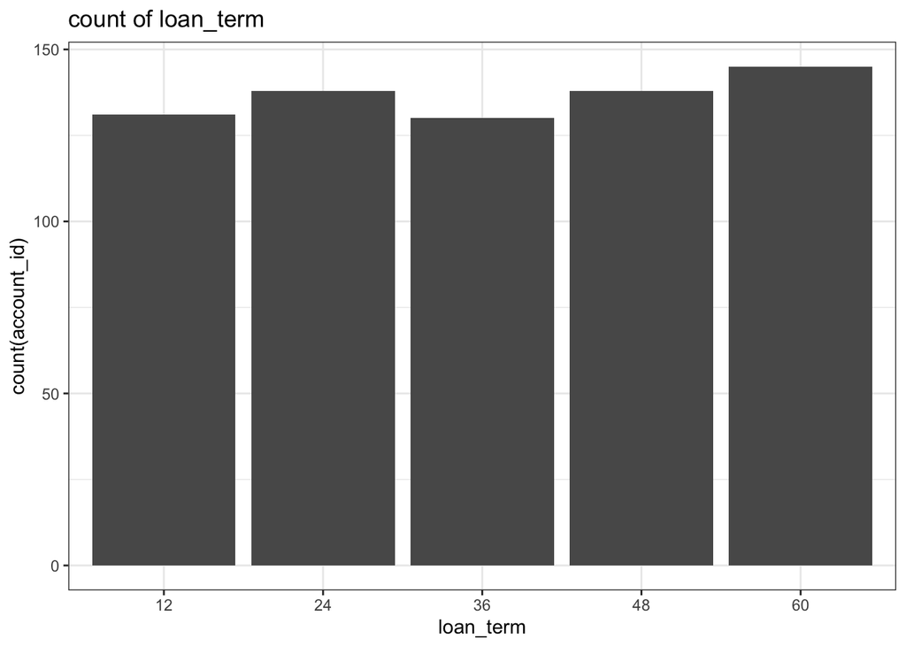

```r
# graph 1:
ggplot(
  data = accounts[!(is.na(accounts$loan_date)),], # this is to get rid of plotting NA
  mapping = aes(
    x = factor(loan_term)),
    fill = color
) +
  geom_bar()+
  # scale_x_date(labels = date_format("%Y")) +
  #facet_wrap(~loan_term) +
  theme_bw() +
  labs(x="loan_term", y="count(account_id)", title = 'count of loan_term')
```

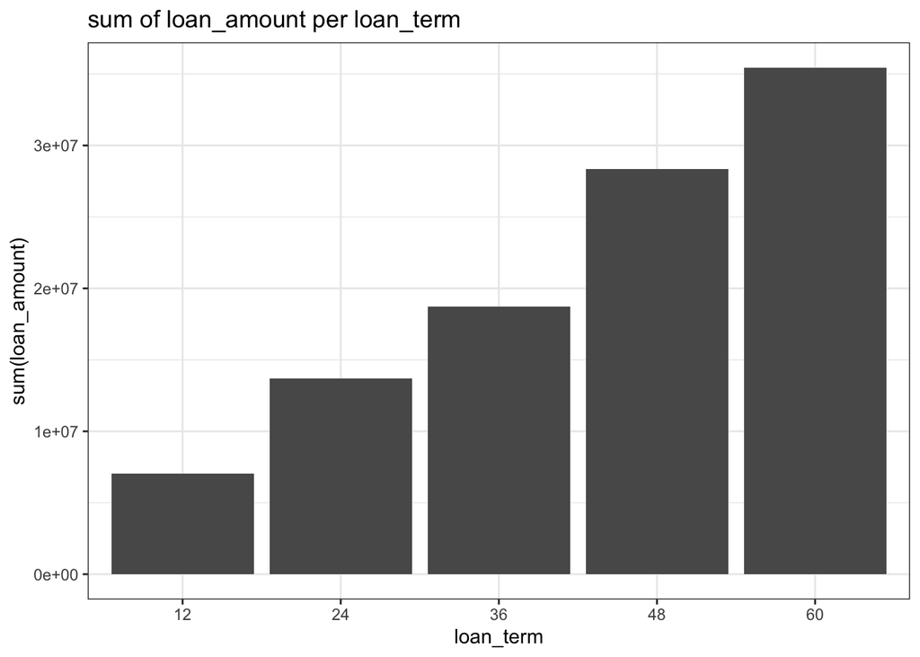

```r
ggplot(
  data = accounts[!(is.na(accounts$loan_date)),], # this is to get rid of plotting NA
  mapping = aes(
    x = factor(loan_term),
    y = loan_amount
)) +
  stat_summary(fun.y = sum, geom = 'bar')+
  theme_bw() +
  labs(x="loan_term", y="sum(loan_amount)", title = 'sum of loan_amount per loan_term')
```

2.5 Onto loan_status, from the graph below we can see most loans are current, almost double the size of expired loans.

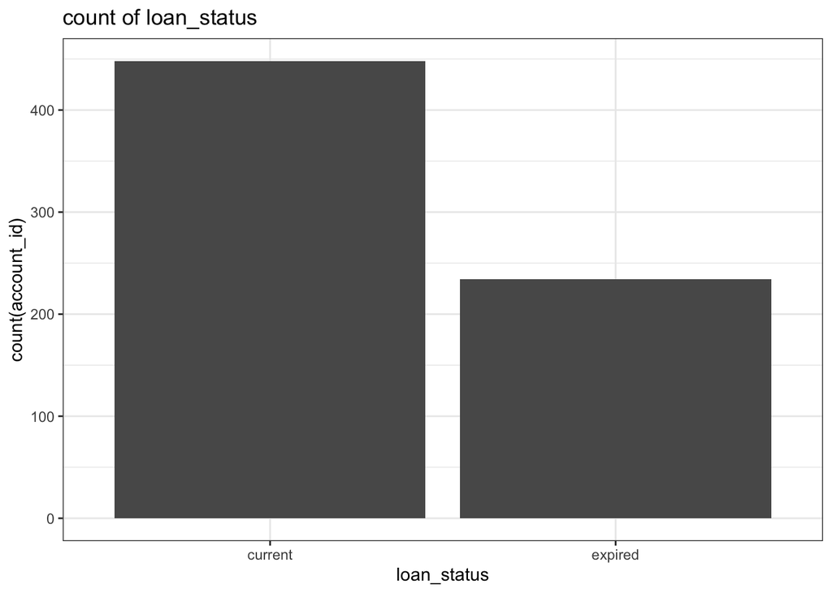

```r
# graph 1:
ggplot(
  data = accounts[!(is.na(accounts$loan_date)),], # this is to get rid of plotting NA
  mapping = aes(
    x = loan_status
)) +
  geom_bar()+
  # scale_x_date(labels = date_format("%Y")) +
  #facet_wrap(~loan_term) +
  theme_bw() +
  labs(x="loan_status", y="count(account_id)", title = 'count of loan_status')
```

2.6 Finally onto loan_default. It’s a good sign that the majority of loans are not default and only a small proportionf of loans are dafault.

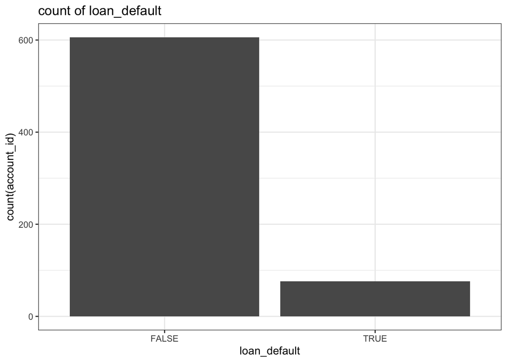

```r
ggplot(
  data = accounts[!(is.na(accounts$loan_date)),], # this is to get rid of plotting NA
  mapping = aes(
    x = loan_default
)) +
  geom_bar()+
  # scale_x_date(labels = date_format("%Y")) +
  #facet_wrap(~loan_term) +
  theme_bw() +
  labs(x="loan_default", y="count(account_id)", title = 'count of loan_default')
```